# Predicting the Prices of Homes (MLR)

- clear your environment

```r
rm(list = ls(all=TRUE))
```

# Agenda

- Get the data
- Ask an interesting question
- Explore the data
- Data Pre-processing
- Model the data
- Evaluation

# Reading & Understanding the Data

- Load the data from working directory

```r
path <- getwd()
setwd(path)
housing_data <- read.csv("housing_data.csv")
```

- Get a feel for the dataset.

```r
str(housing_data)
```

```
## 'data.frame':    506 obs. of  14 variables:
##  $ CRIM : num  0.00632 0.02731 0.02729 0.03237 0.06905 ...
##  $ ZN   : num  18 0 0 NA 0 0 12.5 12.5 12.5 12.5 ...
##  $ INDUS: num  2.31 7.07 7.07 2.18 2.18 ...
##  $ CHAS : int  0 0 0 0 0 0 0 0 0 0 ...
##  $ NOX  : num  0.538 0.469 0.469 0.458 0.458 ...
##  $ RM   : num  6.57 6.42 7.18 7 7.15 ...
##  $ AGE  : num  65.2 78.9 61.1 45.8 54.2 ...
##  $ DIS  : num  4.09 4.97 4.97 6.06 6.06 ...
##  $ RAD  : int  1 2 2 3 3 3 5 5 5 5 ...
##  $ TAX  : int  296 242 242 222 222 222 311 311 311 311 ...
##  $ PT   : num  15.3 17.8 17.8 18.7 18.7 ...
##  $ B    : num  NA 397 393 395 397 ...
##  $ LSTAT: num  4.98 9.14 4.03 2.94 5.33 ...
##  $ MV   : num  24 21.6 34.7 33.4 36.2 ...
```

- The dataset has 506 rows and 14 columns.
- The column/variable names’ explanation is given below:
1. **CRIM :** Per capita Crime rate by town
2. **ZN :** Proportion of residential land zoned for lots over 25,000 sq.ft.
3. **INDUS :** Proportion of non-retail business acres per town
4. **CHAS :**_ Charles River dummy variable (= 1 if tract bounds river; 0 otherwise)
5. **NOX :** nitric oxides concentration (parts per 10 million)
6. **RM :** average number of rooms per dwelling
7. **AGE :** proportion of owner-occupied units built prior to 1940
8. **DIS :** weighted distances to five Boston employment centres
9. **RAD :** index of accessibility to radial highways
10. **TAX :** full-value property-tax rate per $10,000
11. **PTRATIO :** pupil-teacher ratio by town
12. **B :** 1000(Bk - 0.63)^2 where Bk is the proportion of African-Americans by town
13. **LSTAT :** Percentage of the population in the lower economic status
14. **MEDV :** Median value of owner-occupied homes in multiples of $1000
- Take a look at the data

```r
head(housing_data)
```

```
##      CRIM ZN INDUS CHAS   NOX    RM  AGE    DIS RAD TAX   PT      B LSTAT
## 1 0.00632 18  2.31    0 0.538 6.575 65.2 4.0900   1 296 15.3     NA  4.98
## 2 0.02731  0  7.07    0 0.469 6.421 78.9 4.9671   2 242 17.8 396.90  9.14
## 3 0.02729  0  7.07    0 0.469 7.185 61.1 4.9671   2 242 17.8 392.83  4.03
## 4 0.03237 NA  2.18    0 0.458 6.998 45.8 6.0622   3 222 18.7 394.63  2.94
## 5 0.06905  0  2.18    0 0.458 7.147 54.2 6.0622   3 222 18.7 396.90  5.33
## 6 0.02985  0  2.18    0 0.458 6.430 58.7 6.0622   3 222 18.7 394.12  5.21
##     MV
## 1 24.0
## 2 21.6
## 3 34.7
## 4 33.4
## 5 36.2
## 6 28.7
```

```r
tail(housing_data)
```

```
##        CRIM ZN INDUS CHAS   NOX    RM  AGE    DIS RAD TAX   PT      B
## 501 0.22438  0  9.69    0 0.585 6.027 79.7 2.4982   6 391 19.2 396.90
## 502 0.06263  0 11.93    0 0.573 6.593 69.1 2.4786   1 273 21.0 391.99
## 503 0.04527  0 11.93    0 0.573 6.120 76.7 2.2875   1 273 21.0 396.90
## 504 0.06076  0 11.93    0    NA 6.976 91.0 2.1675   1 273 21.0 396.90
## 505 0.10959  0 11.93    0 0.573 6.794 89.3 2.3889   1 273 21.0 393.45
## 506 0.04741  0 11.93    0 0.573 6.030 80.8 2.5050   1 273 21.0 396.90
##     LSTAT   MV
## 501 14.33 16.8
## 502  9.67 22.4
## 503  9.08 20.6
## 504  5.64 23.9
## 505  6.48 22.0
## 506  7.88 11.9
```

- Predict the prices of houses!!

# Exploratory Analysis

## Summary Statistics

- Understand the distribution of various variables:

```r
summary(housing_data)
```

```
##       CRIM                ZN             INDUS            CHAS
##  Min.   : 0.00632   Min.   :  0.00   Min.   : 0.46   Min.   :0.00000
##  1st Qu.: 0.08193   1st Qu.:  0.00   1st Qu.: 5.19   1st Qu.:0.00000
##  Median : 0.26169   Median :  0.00   Median : 9.69   Median :0.00000
##  Mean   : 3.64349   Mean   : 11.35   Mean   :11.14   Mean   :0.06986
##  3rd Qu.: 3.68567   3rd Qu.: 12.50   3rd Qu.:18.10   3rd Qu.:0.00000
##  Max.   :88.97620   Max.   :100.00   Max.   :27.74   Max.   :1.00000
##  NA's   :7          NA's   :8        NA's   :5       NA's   :5
##       NOX               RM             AGE              DIS
##  Min.   :0.3850   Min.   :3.561   Min.   :  2.90   Min.   : 1.130
##  1st Qu.:0.4487   1st Qu.:5.887   1st Qu.: 44.70   1st Qu.: 2.100
##  Median :0.5380   Median :6.210   Median : 77.30   Median : 3.207
##  Mean   :0.5540   Mean   :6.289   Mean   : 68.50   Mean   : 3.791
##  3rd Qu.:0.6240   3rd Qu.:6.628   3rd Qu.: 94.05   3rd Qu.: 5.118
##  Max.   :0.8710   Max.   :8.780   Max.   :100.00   Max.   :12.127
##  NA's   :6        NA's   :4       NA's   :3        NA's   :4
##       RAD              TAX              PT              B
##  Min.   : 1.000   Min.   :187.0   Min.   :12.60   Min.   :  0.32
##  1st Qu.: 4.000   1st Qu.:279.0   1st Qu.:17.40   1st Qu.:375.24
##  Median : 5.000   Median :330.0   Median :19.10   Median :391.38
##  Mean   : 9.561   Mean   :407.8   Mean   :18.46   Mean   :356.38
##  3rd Qu.:24.000   3rd Qu.:666.0   3rd Qu.:20.20   3rd Qu.:396.23
##  Max.   :24.000   Max.   :711.0   Max.   :22.00   Max.   :396.90
##  NA's   :5        NA's   :6       NA's   :9       NA's   :4
##      LSTAT             MV
##  Min.   : 1.73   Min.   : 5.00
##  1st Qu.: 6.99   1st Qu.:17.07
##  Median :11.39   Median :21.20
##  Mean   :12.65   Mean   :22.56
##  3rd Qu.:16.95   3rd Qu.:25.00
##  Max.   :37.97   Max.   :50.00
##  NA's   :6       NA's   :6
```

## Scatter Plots

- A few bi-variate relationships are plotted below:

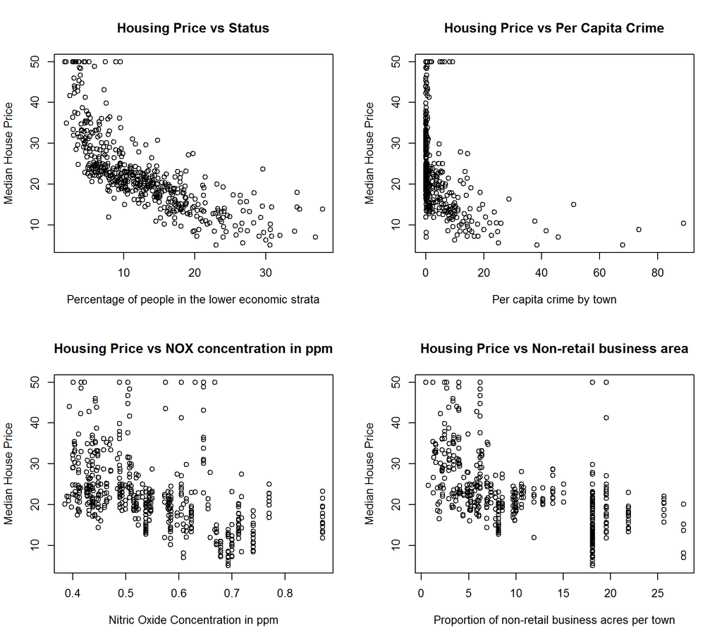

```r
par(mfrow = c(2,2))

plot(housing_data$LSTAT, housing_data$MV, ylab = "Median House Price", xlab = "Percentage of people in the lower economic strata", main = "Housing Price vs Status")

plot(housing_data$CRIM, housing_data$MV, ylab = "Median House Price", xlab = "Per capita crime by town", main = "Housing Price vs Per Capita Crime")

plot(housing_data$NOX, housing_data$MV, ylab = "Median House Price", xlab = "Nitric Oxide Concentration in ppm", main = "Housing Price vs NOX concentration in ppm")

plot(housing_data$INDUS, housing_data$MV, ylab = "Median House Price", xlab = "Proportion of non-retail business acres per town", main = "Housing Price vs Non-retail business area")
```

## Correlation Plot

- Correlations between the variables in the dataset

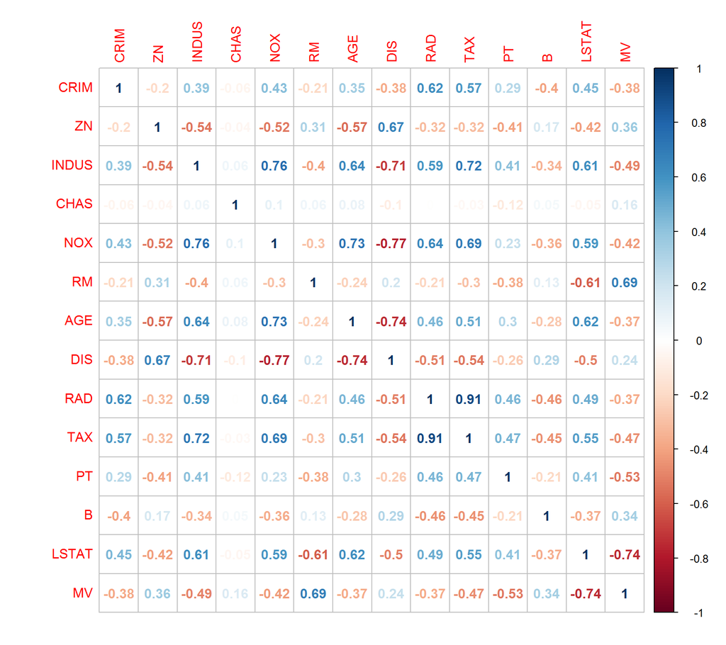

```r
library(corrplot)
corrplot(cor(housing_data, use = "complete.obs"), method = "number")
```

# Data Pre-processing

- Impute missing values and standardize the data after splitting the data into train and test sets

## Train/Test Split

```r
set.seed(29)

# the "sample()" function helps us to randomly sample 70% of the row indices of the dataset

train_rows <- sample(x = 1:nrow(housing_data), size = 0.7*nrow(housing_data))

# We use the above indices to subset the train and test sets from the data

train_data <- housing_data[train_rows, ]

test_data <- housing_data[-train_rows, ]
```

## Missing Values imputation

- Find out the number of missing values in the dataset

```r
sum(is.na(train_data))
```

```
## [1] 49
```

```r
library(caret)
imputer_values <- preProcess(x = train_data, method = "knnImpute")

sum(is.na(train_data))
```

```
## [1] 49
```

```r
train_data <- predict(object = imputer_values, newdata = train_data)

sum(is.na(train_data))
```

```
## [1] 0
```

```r
sum(is.na(test_data))
```

```
## [1] 29
```

```r
test_data <- predict(object = imputer_values, newdata = test_data)

sum(is.na(test_data))
```

```
## [1] 0
```

## Standardizing the Data

```r
library(caret)

# The "preProcess()" function creates a model object required for standardizing unseen data

std_model <- preProcess(train_data[, !names(train_data) %in% c("MV")], method = c("center", "scale"))

# The predict() function is used to standardize any other unseen data

train_data[, !names(train_data) %in% c("MV")] <- predict(object = std_model, newdata = train_data[, !names(train_data) %in% c("MV")])

test_data[, !names(train_data) %in% c("MV")] <- predict(object = std_model, newdata = test_data[, !names(train_data) %in% c("MV")])
```

# Modelling the Data

## Basic Model

- The “.” adds all the variables other than the response variable while building the model.

```r
model_basic <- lm(formula = MV~. , data = train_data)

summary(model_basic)
```

```
##
## Call:
## lm(formula = MV ~ ., data = train_data)
##
## Residuals:
##      Min       1Q   Median       3Q      Max
## -1.26317 -0.31205 -0.08097  0.18986  2.81156
##
## Coefficients:
##              Estimate Std. Error t value Pr(>|t|)
## (Intercept) -0.002670   0.028110  -0.095 0.924389
## CRIM        -0.078277   0.040816  -1.918 0.055976 .
## ZN           0.133081   0.042150   3.157 0.001735 **
## INDUS        0.024544   0.055650   0.441 0.659470
## CHAS         0.090623   0.029126   3.111 0.002020 **
## NOX         -0.227902   0.058751  -3.879 0.000126 ***
## RM           0.292411   0.039262   7.448 7.90e-13 ***
## AGE         -0.008042   0.049856  -0.161 0.871948
## DIS         -0.364681   0.057383  -6.355 6.69e-10 ***
## RAD          0.309282   0.079501   3.890 0.000120 ***
## TAX         -0.219321   0.086817  -2.526 0.011982 *
## PT          -0.205609   0.036821  -5.584 4.82e-08 ***
## B            0.097031   0.033502   2.896 0.004021 **
## LSTAT       -0.429977   0.047718  -9.011  < 2e-16 ***
## ---
## Signif. codes:  0 '***' 0.001 '**' 0.01 '*' 0.05 '.' 0.1 ' ' 1
##
## Residual standard error: 0.5289 on 340 degrees of freedom
## Multiple R-squared:  0.7275, Adjusted R-squared:  0.7171
## F-statistic: 69.84 on 13 and 340 DF,  p-value: < 2.2e-16
```

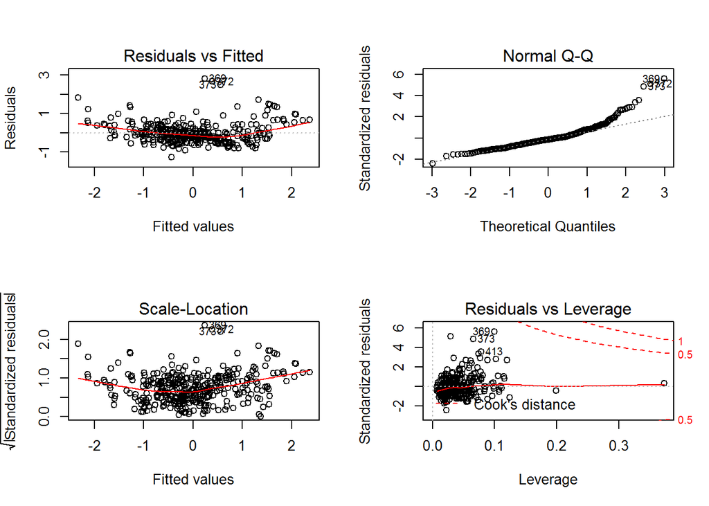

```r
par(mfrow = c(2,2))

plot(model_basic)
```

## stepAIC model

- stepAIC uses AIC (Akaike information criterion) to either drop variables (“backward” direction) or add variables (“forward” direction) from the model

```r
library(MASS)

model_aic <- stepAIC(model_basic, direction = "both")
```

```
## Start:  AIC=-437.28
## MV ~ CRIM + ZN + INDUS + CHAS + NOX + RM + AGE + DIS + RAD +
##     TAX + PT + B + LSTAT
##
##         Df Sum of Sq     RSS     AIC
## - AGE    1    0.0073  95.109 -439.25
## - INDUS  1    0.0544  95.156 -439.08
## <none>                95.102 -437.28
## - CRIM   1    1.0288  96.131 -435.47
## - TAX    1    1.7851  96.887 -432.70
## - B      1    2.3463  97.448 -430.65
## - CHAS   1    2.7078  97.810 -429.34
## - ZN     1    2.7883  97.890 -429.05
## - NOX    1    4.2090  99.311 -423.95
## - RAD    1    4.2332  99.335 -423.86
## - PT     1    8.7217 103.824 -408.22
## - DIS    1   11.2973 106.399 -399.54
## - RM     1   15.5150 110.617 -385.78
## - LSTAT  1   22.7106 117.813 -363.47
##
## Step:  AIC=-439.25
## MV ~ CRIM + ZN + INDUS + CHAS + NOX + RM + DIS + RAD + TAX +
##     PT + B + LSTAT
##
##         Df Sum of Sq     RSS     AIC
## - INDUS  1    0.0562  95.165 -441.04
## <none>                95.109 -439.25
## - CRIM   1    1.0348  96.144 -437.42
## + AGE    1    0.0073  95.102 -437.28
## - TAX    1    1.8224  96.932 -434.53
## - B      1    2.3412  97.451 -432.64
## - CHAS   1    2.7014  97.811 -431.34
## - ZN     1    2.8208  97.930 -430.91
## - RAD    1    4.3426  99.452 -425.45
## - NOX    1    4.6255  99.735 -424.44
## - PT     1    8.8351 103.944 -409.81
## - DIS    1   12.6145 107.724 -397.16
## - RM     1   15.8373 110.947 -386.73
## - LSTAT  1   24.8287 119.938 -359.14
##
## Step:  AIC=-441.04
## MV ~ CRIM + ZN + CHAS + NOX + RM + DIS + RAD + TAX + PT + B +
##     LSTAT
##
##         Df Sum of Sq     RSS     AIC
## <none>                95.165 -441.04
## + INDUS  1    0.0562  95.109 -439.25
## - CRIM   1    1.0655  96.231 -439.10
## + AGE    1    0.0090  95.156 -439.08
## - TAX    1    1.8997  97.065 -436.05
## - B      1    2.3127  97.478 -434.54
## - CHAS   1    2.7528  97.918 -432.95
## - ZN     1    2.7705  97.936 -432.88
## - RAD    1    4.3671  99.533 -427.16
## - NOX    1    4.6510  99.817 -426.15
## - PT     1    8.8041 103.970 -411.72
## - DIS    1   13.8592 109.025 -394.91
## - RM     1   15.8201 110.986 -388.60
## - LSTAT  1   24.8404 120.006 -360.94
```

```r
summary(model_aic)
```

```
##
## Call:
## lm(formula = MV ~ CRIM + ZN + CHAS + NOX + RM + DIS + RAD + TAX +
##     PT + B + LSTAT, data = train_data)
##
## Residuals:
##      Min       1Q   Median       3Q      Max
## -1.26391 -0.31780 -0.08002  0.19017  2.80427
##
## Coefficients:
##             Estimate Std. Error t value Pr(>|t|)
## (Intercept) -0.00267    0.02804  -0.095  0.92419
## CRIM        -0.07950    0.04063  -1.957  0.05118 .
## ZN           0.13174    0.04175   3.155  0.00175 **
## CHAS         0.09101    0.02894   3.145  0.00180 **
## NOX         -0.22434    0.05487  -4.088 5.42e-05 ***
## RM           0.28947    0.03839   7.540 4.26e-13 ***
## DIS         -0.36737    0.05205  -7.057 9.50e-12 ***
## RAD          0.30217    0.07627   3.962 9.06e-05 ***
## TAX         -0.20433    0.07820  -2.613  0.00938 **
## PT          -0.20570    0.03657  -5.625 3.86e-08 ***
## B            0.09620    0.03337   2.883  0.00419 **
## LSTAT       -0.43006    0.04552  -9.448  < 2e-16 ***
## ---
## Signif. codes:  0 '***' 0.001 '**' 0.01 '*' 0.05 '.' 0.1 ' ' 1
##
## Residual standard error: 0.5275 on 342 degrees of freedom
## Multiple R-squared:  0.7274, Adjusted R-squared:  0.7186
## F-statistic: 82.95 on 11 and 342 DF,  p-value: < 2.2e-16
```

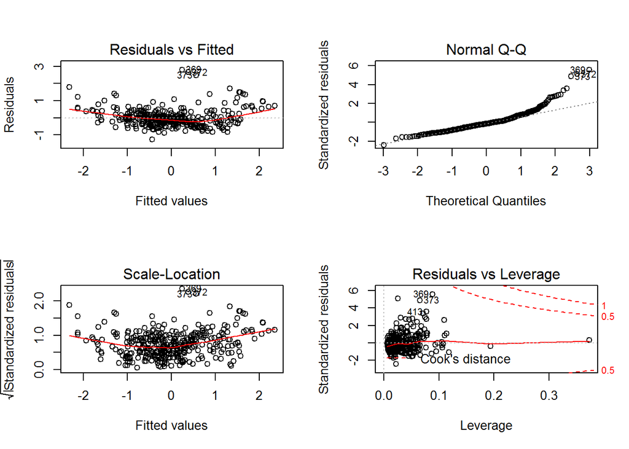

```r
par(mfrow = c(2,2))

plot(model_aic)
```

## Modifying the Model with the VIF

**Variance Inflation Factor :**

$$VIF_{k} = \dfrac{1}{1 - R_{k}^2}$$

$R_{k}^2$ is the R^2-value obtained by regressing the kth predictor on the remaining predictors. VIF gives us an idea of multi-collinearity

- Every explanatory variable would have a VIF score
- A VIF > 4 means that there are signs of multi-collinearity and anything greater than 10 means that an explanatory variable should be dropped

```r
library(car)
vif(model_basic)
```

```
##     CRIM       ZN    INDUS     CHAS      NOX       RM      AGE      DIS
## 2.102462 2.242129 3.908383 1.070613 4.356021 1.945409 3.136906 4.155532
##      RAD      TAX       PT        B    LSTAT
## 7.976448 9.512061 1.711033 1.416484 2.873660
```

```r
vif(model_aic)
```

```
##     CRIM       ZN     CHAS      NOX       RM      DIS      RAD      TAX
## 2.093954 2.211404 1.062152 3.819610 1.869765 3.437588 7.380569 7.757735
##       PT        B    LSTAT
## 1.696510 1.412536 2.628241
```

- After applying the stepAIC, the VIF values have slightly reduced, but the variables “RAD” and “TAX” have VIF values higher than 4
- Let’s take a look at the correlation between the “RAD” and “TAX” variables

```r
cor(housing_data$RAD, housing_data$TAX)
```

```
## [1] NA
```

```r
model3 <- lm(formula = MV ~ CRIM + ZN + CHAS + NOX + RM + DIS + RAD + PT + B + LSTAT, data = train_data)

summary(model3)
```

```
##
## Call:
## lm(formula = MV ~ CRIM + ZN + CHAS + NOX + RM + DIS + RAD + PT +
##     B + LSTAT, data = train_data)
##
## Residuals:
##      Min       1Q   Median       3Q      Max
## -1.26704 -0.34951 -0.07068  0.19485  2.80089
##
## Coefficients:
##             Estimate Std. Error t value Pr(>|t|)
## (Intercept) -0.00267    0.02827  -0.094 0.924826
## CRIM        -0.07237    0.04088  -1.770 0.077537 .
## ZN           0.11270    0.04146   2.718 0.006895 **
## CHAS         0.09734    0.02908   3.347 0.000906 ***
## NOX         -0.25500    0.05405  -4.717 3.48e-06 ***
## RM           0.30247    0.03839   7.879 4.42e-14 ***
## DIS         -0.35134    0.05213  -6.740 6.73e-11 ***
## RAD          0.14746    0.04849   3.041 0.002539 **
## PT          -0.21772    0.03659  -5.951 6.58e-09 ***
## B            0.10204    0.03358   3.039 0.002555 **
## LSTAT       -0.43961    0.04575  -9.608  < 2e-16 ***
## ---
## Signif. codes:  0 '***' 0.001 '**' 0.01 '*' 0.05 '.' 0.1 ' ' 1
##
## Residual standard error: 0.532 on 343 degrees of freedom
## Multiple R-squared:  0.7219, Adjusted R-squared:  0.7138
## F-statistic: 89.04 on 10 and 343 DF,  p-value: < 2.2e-16
```

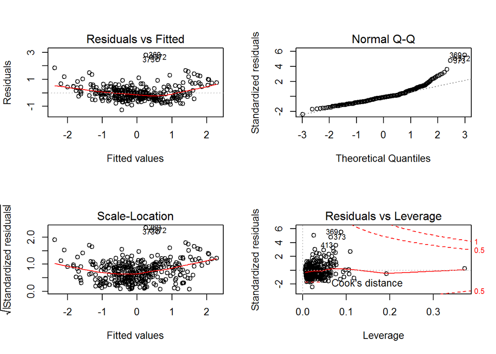

```r
par(mfrow = c(2,2))

plot(model3)
```

```r
vif(model3)
```

```
##     CRIM       ZN     CHAS      NOX       RM      DIS      RAD       PT
## 2.084519 2.143996 1.054713 3.644853 1.838395 3.389811 2.933039 1.669660
##        B    LSTAT
## 1.406199 2.611277
```

# Evaluation and Selection of Model

## Picking the Right Model

- The third model built after verifying the vif scores has a similar adjusted R^2 score compared to the previous models with significantly lower no. of explanatory variables and inter-variable interactions.
- The VIF values of the predictors in the third model are lower when compared to the the other two models
- Due to the above two reasons we pick the third model

# Communication

## Prediction

Predict the Housing prices of the unseen boston housing data, using the chosen model.

```r
preds_model <- predict(model3, test_data[, !(names(test_data) %in% c("MV"))])
```

## Performance Metrics

### Error Metrics for Regression

- Mean Absolute Error (MAE):

$$MAE = \dfrac{1}{n}\times|\sum_{i = 1}^{n}y_{i} - \hat{y_{i}}|$$

- Mean Squared Error (MSE):

$$MSE = \dfrac{1}{n}\times(\sum_{i = 1}^{n}y_{i} - \hat{y_{i}})^2$$

- Root Mean Squared Error (RMSE):

$$RMSE = \sqrt{\dfrac{1}{n}\times(\sum_{i = 1}^{n}y_{i} - \hat{y_{i}})^2}$$

- Mean Absolute Percentage Error (MAPE):

$$MAPE = \dfrac{100}{n}\times\mid\dfrac{\sum_{i = 1}^{n}y_{i} - \hat{y_{i}}}{y_{i}}\mid$$

### Report Performance Metrics

- Performance metrics

```r
library(DMwR)
regr.eval(test_data$MV, preds_model)
```

```
##       mae       mse      rmse      mape
## 0.4083179 0.2908612 0.5393155 3.3554175
```